# eda_phishing

## 6. Kenyan URLs vs the dataset

```r
source("../R/url_features.R")
phish_url <- readRDS("../data/processed/phishing_url_features.rds")
ke <- read_csv("../data/raw/kenya_urls.csv", show_col_types = FALSE)
ke_feat <- bind_cols(ke, url_features(ke$url))

compare <- bind_rows(
  phish_url |> mutate(group = if_else(is_phishing == "phishing",
                                      "Global phishing", "Global legitimate")),
  ke_feat   |> mutate(group = "Kenyan legitimate")
)

compare |>
  group_by(group) |>
  summarise(n = n(),
            median_url_length = median(url_length),
            pct_with_path = round(100 * mean(path_length > 1), 1),
            pct_https = round(100 * mean(is_https), 1))
```

```
# A tibble: 3 × 5
  group                  n median_url_length pct_with_path pct_https
  <chr>              <int>             <dbl>         <dbl>     <dbl>
1 Global legitimate 134850                27           0       100
2 Global phishing   100945                34          28.4      48.7
3 Kenyan legitimate    348                35          58.3     100
```

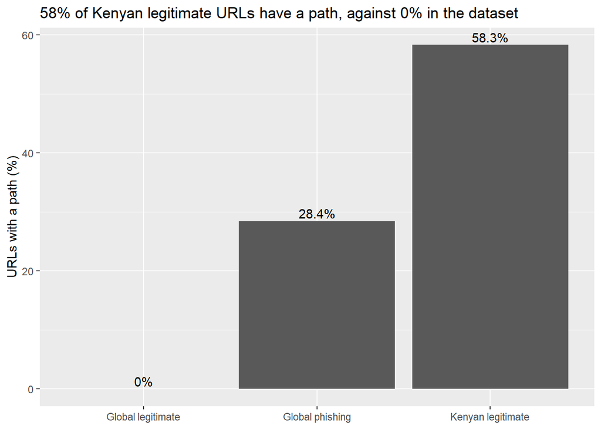

```r
compare |>
  group_by(group) |>
  summarise(pct_with_path = 100 * mean(path_length > 1)) |>
  ggplot(aes(reorder(group, pct_with_path), pct_with_path)) +
  geom_col() +
  geom_text(aes(label = paste0(round(pct_with_path, 1), "%")), vjust = -0.3) +
  labs(title = "58% of Kenyan legitimate URLs have a path, against 0% in the dataset",
       x = NULL, y = "URLs with a path (%)")
```

## 7. Findings

1. The dataset has 235,795 URLs and 57 columns with no missing values; 100,945 (42.8%) are phishing and 134,850 (57.2%) are legitimate.
2. All 134,850 legitimate URLs use https, start with www and have no path, so the legitimate class is made only of bare homepages.
3. Among the 100,945 phishing URLs, 48.7% use https, 41.4% start with www and 28.4% have a path.
4. Phishing URLs show extreme values for length (up to about 6,000 characters) and special characters (up to about 500), while legitimate URLs stay short.
5. URLSimilarityIndex separates the classes almost perfectly on its own (AUC 0.996) and is a suspected leak.
6. LineOfCode (0.990), NoOfExternalRef (0.988) and NoOfImage (0.980) also pass the 0.98 threshold.
7. The top seven features by AUC are all page-content features that need the page to be visited, so they cannot be measured from URL text alone.
8. The strongest URL-text features are NoOfOtherSpecialCharsInURL (AUC 0.824) and SpacialCharRatioInURL (0.808), well below the page-content features.
9. Because legitimate URLs are only bare homepages, a model may learn URL structure instead of phishing behaviour, which Part 4 tests on real Kenyan login and deep-link pages.
10. The naive and Kenya-aware subdomain counts differ for only 79 of 235,795 URLs (0.03%), so the average count is the same either way (1.17 for phishing, 1.16 for legitimate).
11. Only 81 URLs in the dataset end in .ke (49 legitimate and 32 phishing), so a model trained on it has almost never seen Kenyan domains.
12. On safaricom.co.ke the naive count is 2 and the fixed count is 1, the same as kcbgroup.com, so the naive count could make a Kenyan site look more suspicious, which Part 4 will test.
13. 58.3% of the 348 Kenyan legitimate URLs contain a path, compared with 0% of the 134,850 legitimate URLs in PhiUSIIL and 28.4% of its phishing URLs.
14. The median Kenyan URL is 35 characters, close to phishing (34) and longer than global legitimate URLs (27).
15. The gap is driven by page type: 95.2% of Kenyan deep pages and 75% of login or service pages have a path, against 4.1% of homepages.
16. Kenyan homepages resemble the dataset’s legitimate URLs (median 25 characters vs 27), so a model trained on PhiUSIIL has only seen the homepage shape of legitimate sites.